# INTRODUCTION

We have a dataset of above 10,000 that is dervived from the movie industry. It includes information about the popularity of various genres of movies, including the run time of the movies, and how viewers rated the movies. Additional information such as the budget of each movies,the production companies, the directors, and cast of the movies was also disclosed as this might be among the various reasons why a particular movie might turn out the way it did, in terms of average votes and popularity. The genre and release year of the movie is also an essential information to draw up any reasonable conclusion.

# QUESTION FOR ANALYSIS

1. How did the release year affect popularity
2. Which genre has the highest popularity?
3. What is the average popularity of each genre?
4. Did the production company affect the popularity?
5. Which Gnere produced more movies?

```python
# Use this cell to set up import statements for all of the packages that you
#   plan to use.

import numpy as np
import pandas as pd
import matplotlib.pyplot as plt
import seaborn as sns
%matplotlib inline
```

# DATA WRANGLING

```python
# Load your data and print out a few lines. Perform operations to inspect data
#   types and look for instances of missing or possibly errant data.

df = pd.read_csv('tmdb-movies.csv')
df.head()
```

|  | id | imdb_id | popularity | budget | revenue | original_title | cast | homepage | director | tagline | ... | overview | runtime | genres | production_companies | release_date | vote_count | vote_average | release_year | budget_adj | revenue_adj |
| --- | --- | --- | --- | --- | --- | --- | --- | --- | --- | --- | --- | --- | --- | --- | --- | --- | --- | --- | --- | --- | --- |
| 0 | 135397 | tt0369610 | 32.985763 | 150000000 | 1513528810 | Jurassic World | Chris Pratt\|Bryce Dallas Howard\|Irrfan Khan\|Vi... | http://www.jurassicworld.com/ | Colin Trevorrow | The park is open. | ... | Twenty-two years after the events of Jurassic ... | 124 | Action\|Adventure\|Science Fiction\|Thriller | Universal Studios\|Amblin Entertainment\|Legenda... | 6/9/15 | 5562 | 6.5 | 2015 | 1.379999e+08 | 1.392446e+09 |
| 1 | 76341 | tt1392190 | 28.419936 | 150000000 | 378436354 | Mad Max: Fury Road | Tom Hardy\|Charlize Theron\|Hugh Keays-Byrne\|Nic... | http://www.madmaxmovie.com/ | George Miller | What a Lovely Day. | ... | An apocalyptic story set in the furthest reach... | 120 | Action\|Adventure\|Science Fiction\|Thriller | Village Roadshow Pictures\|Kennedy Miller Produ... | 5/13/15 | 6185 | 7.1 | 2015 | 1.379999e+08 | 3.481613e+08 |
| 2 | 262500 | tt2908446 | 13.112507 | 110000000 | 295238201 | Insurgent | Shailene Woodley\|Theo James\|Kate Winslet\|Ansel... | http://www.thedivergentseries.movie/#insurgent | Robert Schwentke | One Choice Can Destroy You | ... | Beatrice Prior must confront her inner demons ... | 119 | Adventure\|Science Fiction\|Thriller | Summit Entertainment\|Mandeville Films\|Red Wago... | 3/18/15 | 2480 | 6.3 | 2015 | 1.012000e+08 | 2.716190e+08 |
| 3 | 140607 | tt2488496 | 11.173104 | 200000000 | 2068178225 | Star Wars: The Force Awakens | Harrison Ford\|Mark Hamill\|Carrie Fisher\|Adam D... | http://www.starwars.com/films/star-wars-episod... | J.J. Abrams | Every generation has a story. | ... | Thirty years after defeating the Galactic Empi... | 136 | Action\|Adventure\|Science Fiction\|Fantasy | Lucasfilm\|Truenorth Productions\|Bad Robot | 12/15/15 | 5292 | 7.5 | 2015 | 1.839999e+08 | 1.902723e+09 |
| 4 | 168259 | tt2820852 | 9.335014 | 190000000 | 1506249360 | Furious 7 | Vin Diesel\|Paul Walker\|Jason Statham\|Michelle ... | http://www.furious7.com/ | James Wan | Vengeance Hits Home | ... | Deckard Shaw seeks revenge against Dominic Tor... | 137 | Action\|Crime\|Thriller | Universal Pictures\|Original Film\|Media Rights ... | 4/1/15 | 2947 | 7.3 | 2015 | 1.747999e+08 | 1.385749e+09 |

5 rows × 21 columns

```python
#To get more details on my data set
# An anomaly is spotted in the budget and revenue column


df.describe()
```

|  | id | popularity | budget | revenue | runtime | vote_count | vote_average | release_year | budget_adj | revenue_adj |
| --- | --- | --- | --- | --- | --- | --- | --- | --- | --- | --- |
| count | 10866.000000 | 10866.000000 | 1.086600e+04 | 1.086600e+04 | 10866.000000 | 10866.000000 | 10866.000000 | 10866.000000 | 1.086600e+04 | 1.086600e+04 |
| mean | 66064.177434 | 0.646441 | 1.462570e+07 | 3.982332e+07 | 102.070863 | 217.389748 | 5.974922 | 2001.322658 | 1.755104e+07 | 5.136436e+07 |
| std | 92130.136561 | 1.000185 | 3.091321e+07 | 1.170035e+08 | 31.381405 | 575.619058 | 0.935142 | 12.812941 | 3.430616e+07 | 1.446325e+08 |
| min | 5.000000 | 0.000065 | 0.000000e+00 | 0.000000e+00 | 0.000000 | 10.000000 | 1.500000 | 1960.000000 | 0.000000e+00 | 0.000000e+00 |
| 25% | 10596.250000 | 0.207583 | 0.000000e+00 | 0.000000e+00 | 90.000000 | 17.000000 | 5.400000 | 1995.000000 | 0.000000e+00 | 0.000000e+00 |
| 50% | 20669.000000 | 0.383856 | 0.000000e+00 | 0.000000e+00 | 99.000000 | 38.000000 | 6.000000 | 2006.000000 | 0.000000e+00 | 0.000000e+00 |
| 75% | 75610.000000 | 0.713817 | 1.500000e+07 | 2.400000e+07 | 111.000000 | 145.750000 | 6.600000 | 2011.000000 | 2.085325e+07 | 3.369710e+07 |
| max | 417859.000000 | 32.985763 | 4.250000e+08 | 2.781506e+09 | 900.000000 | 9767.000000 | 9.200000 | 2015.000000 | 4.250000e+08 | 2.827124e+09 |

```python
#to get the conscise

df.info()
```

```
<class 'pandas.core.frame.DataFrame'>
RangeIndex: 10866 entries, 0 to 10865
Data columns (total 21 columns):
 #   Column                Non-Null Count  Dtype
---  ------                --------------  -----
 0   id                    10866 non-null  int64
 1   imdb_id               10856 non-null  object
 2   popularity            10866 non-null  float64
 3   budget                10866 non-null  int64
 4   revenue               10866 non-null  int64
 5   original_title        10866 non-null  object
 6   cast                  10790 non-null  object
 7   homepage              2936 non-null   object
 8   director              10822 non-null  object
 9   tagline               8042 non-null   object
 10  keywords              9373 non-null   object
 11  overview              10862 non-null  object
 12  runtime               10866 non-null  int64
 13  genres                10843 non-null  object
 14  production_companies  9836 non-null   object
 15  release_date          10866 non-null  object
 16  vote_count            10866 non-null  int64
 17  vote_average          10866 non-null  float64
 18  release_year          10866 non-null  int64
 19  budget_adj            10866 non-null  float64
 20  revenue_adj           10866 non-null  float64
dtypes: float64(4), int64(6), object(11)
memory usage: 1.7+ MB
```

```python
#To verify if and where they are Non Values
#The major rows with non values in this output contains string values
#would leave as it is.

df.isnull().sum()
```

```
id                         0
imdb_id                   10
popularity                 0
budget                     0
revenue                    0
original_title             0
cast                      76
homepage                7930
director                  44
tagline                 2824
keywords                1493
overview                   4
runtime                    0
genres                    23
production_companies    1030
release_date               0
vote_count                 0
vote_average               0
release_year               0
budget_adj                 0
revenue_adj                0
dtype: int64
```

```python
df.describe()

#To see the details of the dataframe and observe for any anomaly.
#Found zeros in budget and revenue columns
```

|  | id | popularity | budget | revenue | runtime | vote_count | vote_average | release_year | budget_adj | revenue_adj |
| --- | --- | --- | --- | --- | --- | --- | --- | --- | --- | --- |
| count | 10866.000000 | 10866.000000 | 1.086600e+04 | 1.086600e+04 | 10866.000000 | 10866.000000 | 10866.000000 | 10866.000000 | 1.086600e+04 | 1.086600e+04 |
| mean | 66064.177434 | 0.646441 | 1.462570e+07 | 3.982332e+07 | 102.070863 | 217.389748 | 5.974922 | 2001.322658 | 1.755104e+07 | 5.136436e+07 |
| std | 92130.136561 | 1.000185 | 3.091321e+07 | 1.170035e+08 | 31.381405 | 575.619058 | 0.935142 | 12.812941 | 3.430616e+07 | 1.446325e+08 |
| min | 5.000000 | 0.000065 | 0.000000e+00 | 0.000000e+00 | 0.000000 | 10.000000 | 1.500000 | 1960.000000 | 0.000000e+00 | 0.000000e+00 |
| 25% | 10596.250000 | 0.207583 | 0.000000e+00 | 0.000000e+00 | 90.000000 | 17.000000 | 5.400000 | 1995.000000 | 0.000000e+00 | 0.000000e+00 |
| 50% | 20669.000000 | 0.383856 | 0.000000e+00 | 0.000000e+00 | 99.000000 | 38.000000 | 6.000000 | 2006.000000 | 0.000000e+00 | 0.000000e+00 |
| 75% | 75610.000000 | 0.713817 | 1.500000e+07 | 2.400000e+07 | 111.000000 | 145.750000 | 6.600000 | 2011.000000 | 2.085325e+07 | 3.369710e+07 |
| max | 417859.000000 | 32.985763 | 4.250000e+08 | 2.781506e+09 | 900.000000 | 9767.000000 | 9.200000 | 2015.000000 | 4.250000e+08 | 2.827124e+09 |

```python
#rows with zeros in budget

missing_rows= df[df['budget']==0].shape[0]

missing_rows
```

```
5696
```

```python
#To get the mean for the values in budget column

(df['budget'].mean())
```

```
14625701.09414688
```

```python
#To repkave the zeros with the mean
#View to confirm

df['budget'] = df['budget'].replace(['0'],[14625701.09414688])
df.describe()
```

[output not shown]

```python
#To get the mean for the values in revenuw column

(df['revenue'].mean())
```

```
39823319.79339223
```

```python
#To replace the zeros in  revenue column with the mean
#View to confirm

df['revenue'] = df['revenue'].replace(['0'],[39823319.79339223])
df.describe()
```

[output not shown]

# DATA CLEANING

```python
#To drop unwanted headers

df.drop(['cast', 'homepage', 'director', 'tagline', 'keywords', 'overview', 'runtime', 'vote_count','vote_average','budget_adj','revenue_adj'], axis = 1, inplace = True)
df.head()
```

|  | id | imdb_id | popularity | budget | revenue | original_title | genres | production_companies | release_date | release_year |
| --- | --- | --- | --- | --- | --- | --- | --- | --- | --- | --- |
| 0 | 135397 | tt0369610 | 32.985763 | 150000000.0 | 1.513529e+09 | Jurassic World | Action\|Adventure\|Science Fiction\|Thriller | Universal Studios\|Amblin Entertainment\|Legenda... | 6/9/15 | 2015 |
| 1 | 76341 | tt1392190 | 28.419936 | 150000000.0 | 3.784364e+08 | Mad Max: Fury Road | Action\|Adventure\|Science Fiction\|Thriller | Village Roadshow Pictures\|Kennedy Miller Produ... | 5/13/15 | 2015 |
| 2 | 262500 | tt2908446 | 13.112507 | 110000000.0 | 2.952382e+08 | Insurgent | Adventure\|Science Fiction\|Thriller | Summit Entertainment\|Mandeville Films\|Red Wago... | 3/18/15 | 2015 |
| 3 | 140607 | tt2488496 | 11.173104 | 200000000.0 | 2.068178e+09 | Star Wars: The Force Awakens | Action\|Adventure\|Science Fiction\|Fantasy | Lucasfilm\|Truenorth Productions\|Bad Robot | 12/15/15 | 2015 |
| 4 | 168259 | tt2820852 | 9.335014 | 190000000.0 | 1.506249e+09 | Furious 7 | Action\|Crime\|Thriller | Universal Pictures\|Original Film\|Media Rights ... | 4/1/15 | 2015 |

```python
#To confirm it has been dropped

df.head()
```

|  | id | imdb_id | popularity | budget | revenue | original_title | genres | production_companies | release_date | release_year |
| --- | --- | --- | --- | --- | --- | --- | --- | --- | --- | --- |
| 0 | 135397 | tt0369610 | 32.985763 | 150000000.0 | 1.513529e+09 | Jurassic World | Action\|Adventure\|Science Fiction\|Thriller | Universal Studios\|Amblin Entertainment\|Legenda... | 6/9/15 | 2015 |
| 1 | 76341 | tt1392190 | 28.419936 | 150000000.0 | 3.784364e+08 | Mad Max: Fury Road | Action\|Adventure\|Science Fiction\|Thriller | Village Roadshow Pictures\|Kennedy Miller Produ... | 5/13/15 | 2015 |
| 2 | 262500 | tt2908446 | 13.112507 | 110000000.0 | 2.952382e+08 | Insurgent | Adventure\|Science Fiction\|Thriller | Summit Entertainment\|Mandeville Films\|Red Wago... | 3/18/15 | 2015 |
| 3 | 140607 | tt2488496 | 11.173104 | 200000000.0 | 2.068178e+09 | Star Wars: The Force Awakens | Action\|Adventure\|Science Fiction\|Fantasy | Lucasfilm\|Truenorth Productions\|Bad Robot | 12/15/15 | 2015 |
| 4 | 168259 | tt2820852 | 9.335014 | 190000000.0 | 1.506249e+09 | Furious 7 | Action\|Crime\|Thriller | Universal Pictures\|Original Film\|Media Rights ... | 4/1/15 | 2015 |

```python
#to arrange data in descending order for popularity, and ascending order for genres.
#to view the irst 20 rows

df.sort_values(['popularity', 'genres'], ascending= [False, True])
df.head(20)
```

|  | id | imdb_id | popularity | budget | revenue | original_title | genres | production_companies | release_date | release_year |
| --- | --- | --- | --- | --- | --- | --- | --- | --- | --- | --- |
| 0 | 135397 | tt0369610 | 32.985763 | 150000000.0 | 1.513529e+09 | Jurassic World | Action\|Adventure\|Science Fiction\|Thriller | Universal Studios\|Amblin Entertainment\|Legenda... | 6/9/15 | 2015 |
| 1 | 76341 | tt1392190 | 28.419936 | 150000000.0 | 3.784364e+08 | Mad Max: Fury Road | Action\|Adventure\|Science Fiction\|Thriller | Village Roadshow Pictures\|Kennedy Miller Produ... | 5/13/15 | 2015 |
| 2 | 262500 | tt2908446 | 13.112507 | 110000000.0 | 2.952382e+08 | Insurgent | Adventure\|Science Fiction\|Thriller | Summit Entertainment\|Mandeville Films\|Red Wago... | 3/18/15 | 2015 |
| 3 | 140607 | tt2488496 | 11.173104 | 200000000.0 | 2.068178e+09 | Star Wars: The Force Awakens | Action\|Adventure\|Science Fiction\|Fantasy | Lucasfilm\|Truenorth Productions\|Bad Robot | 12/15/15 | 2015 |
| 4 | 168259 | tt2820852 | 9.335014 | 190000000.0 | 1.506249e+09 | Furious 7 | Action\|Crime\|Thriller | Universal Pictures\|Original Film\|Media Rights ... | 4/1/15 | 2015 |
| 5 | 281957 | tt1663202 | 9.110700 | 135000000.0 | 5.329505e+08 | The Revenant | Western\|Drama\|Adventure\|Thriller | Regency Enterprises\|Appian Way\|CatchPlay\|Anony... | 12/25/15 | 2015 |
| 6 | 87101 | tt1340138 | 8.654359 | 155000000.0 | 4.406035e+08 | Terminator Genisys | Science Fiction\|Action\|Thriller\|Adventure | Paramount Pictures\|Skydance Productions | 6/23/15 | 2015 |
| 7 | 286217 | tt3659388 | 7.667400 | 108000000.0 | 5.953803e+08 | The Martian | Drama\|Adventure\|Science Fiction | Twentieth Century Fox Film Corporation\|Scott F... | 9/30/15 | 2015 |
| 8 | 211672 | tt2293640 | 7.404165 | 74000000.0 | 1.156731e+09 | Minions | Family\|Animation\|Adventure\|Comedy | Universal Pictures\|Illumination Entertainment | 6/17/15 | 2015 |
| 9 | 150540 | tt2096673 | 6.326804 | 175000000.0 | 8.537086e+08 | Inside Out | Comedy\|Animation\|Family | Walt Disney Pictures\|Pixar Animation Studios\|W... | 6/9/15 | 2015 |
| 10 | 206647 | tt2379713 | 6.200282 | 245000000.0 | 8.806746e+08 | Spectre | Action\|Adventure\|Crime | Columbia Pictures\|Danjaq\|B24 | 10/26/15 | 2015 |
| 11 | 76757 | tt1617661 | 6.189369 | 176000003.0 | 1.839877e+08 | Jupiter Ascending | Science Fiction\|Fantasy\|Action\|Adventure | Village Roadshow Pictures\|Dune Entertainment\|A... | 2/4/15 | 2015 |
| 12 | 264660 | tt0470752 | 6.118847 | 15000000.0 | 3.686941e+07 | Ex Machina | Drama\|Science Fiction | DNA Films\|Universal Pictures International (UP... | 1/21/15 | 2015 |
| 13 | 257344 | tt2120120 | 5.984995 | 88000000.0 | 2.436371e+08 | Pixels | Action\|Comedy\|Science Fiction | Columbia Pictures\|Happy Madison Productions | 7/16/15 | 2015 |
| 14 | 99861 | tt2395427 | 5.944927 | 280000000.0 | 1.405036e+09 | Avengers: Age of Ultron | Action\|Adventure\|Science Fiction | Marvel Studios\|Prime Focus\|Revolution Sun Studios | 4/22/15 | 2015 |
| 15 | 273248 | tt3460252 | 5.898400 | 44000000.0 | 1.557601e+08 | The Hateful Eight | Crime\|Drama\|Mystery\|Western | Double Feature Films\|The Weinstein Company\|Fil... | 12/25/15 | 2015 |
| 16 | 260346 | tt2446042 | 5.749758 | 48000000.0 | 3.257714e+08 | Taken 3 | Crime\|Action\|Thriller | Twentieth Century Fox Film Corporation\|M6 Film... | 1/1/15 | 2015 |
| 17 | 102899 | tt0478970 | 5.573184 | 130000000.0 | 5.186022e+08 | Ant-Man | Science Fiction\|Action\|Adventure | Marvel Studios | 7/14/15 | 2015 |
| 18 | 150689 | tt1661199 | 5.556818 | 95000000.0 | 5.423514e+08 | Cinderella | Romance\|Fantasy\|Family\|Drama | Walt Disney Pictures\|Genre Films\|Beagle Pug Fi... | 3/12/15 | 2015 |
| 19 | 131634 | tt1951266 | 5.476958 | 160000000.0 | 6.505234e+08 | The Hunger Games: Mockingjay - Part 2 | War\|Adventure\|Science Fiction | Studio Babelsberg\|StudioCanal\|Lionsgate\|Walt D... | 11/18/15 | 2015 |

```python
#To split the grenres into the first category in thestring.
#This would make the data more concise and relevant.

split_genres=df['genres'].str.split('|',n=1, expand=True)
split_genres
```

|  | 0 | 1 |
| --- | --- | --- |
| 0 | Action | Adventure\|Science Fiction\|Thriller |
| 1 | Action | Adventure\|Science Fiction\|Thriller |
| 2 | Adventure | Science Fiction\|Thriller |
| 3 | Action | Adventure\|Science Fiction\|Fantasy |
| 4 | Action | Crime\|Thriller |
| ... | ... | ... |
| 10861 | Documentary | None |
| 10862 | Action | Adventure\|Drama |
| 10863 | Mystery | Comedy |
| 10864 | Action | Comedy |
| 10865 | Horror | None |

10866 rows × 2 columns

```python
df[['genre','others']]= df['genres'].str.split('|',n=1, expand=True)
df.head()
```

|  | id | imdb_id | popularity | budget | revenue | original_title | genres | production_companies | release_date | release_year | genre | others |
| --- | --- | --- | --- | --- | --- | --- | --- | --- | --- | --- | --- | --- |
| 0 | 135397 | tt0369610 | 32.985763 | 150000000.0 | 1.513529e+09 | Jurassic World | Action\|Adventure\|Science Fiction\|Thriller | Universal Studios\|Amblin Entertainment\|Legenda... | 6/9/15 | 2015 | Action | Adventure\|Science Fiction\|Thriller |
| 1 | 76341 | tt1392190 | 28.419936 | 150000000.0 | 3.784364e+08 | Mad Max: Fury Road | Action\|Adventure\|Science Fiction\|Thriller | Village Roadshow Pictures\|Kennedy Miller Produ... | 5/13/15 | 2015 | Action | Adventure\|Science Fiction\|Thriller |
| 2 | 262500 | tt2908446 | 13.112507 | 110000000.0 | 2.952382e+08 | Insurgent | Adventure\|Science Fiction\|Thriller | Summit Entertainment\|Mandeville Films\|Red Wago... | 3/18/15 | 2015 | Adventure | Science Fiction\|Thriller |
| 3 | 140607 | tt2488496 | 11.173104 | 200000000.0 | 2.068178e+09 | Star Wars: The Force Awakens | Action\|Adventure\|Science Fiction\|Fantasy | Lucasfilm\|Truenorth Productions\|Bad Robot | 12/15/15 | 2015 | Action | Adventure\|Science Fiction\|Fantasy |
| 4 | 168259 | tt2820852 | 9.335014 | 190000000.0 | 1.506249e+09 | Furious 7 | Action\|Crime\|Thriller | Universal Pictures\|Original Film\|Media Rights ... | 4/1/15 | 2015 | Action | Crime\|Thriller |

```python
#To drop genres and others as they are no longer needed

df.drop(['genres', 'others'], axis = 1, inplace = True)
df.head()
```

|  | id | imdb_id | popularity | budget | revenue | original_title | production_companies | release_date | release_year | genre |
| --- | --- | --- | --- | --- | --- | --- | --- | --- | --- | --- |
| 0 | 135397 | tt0369610 | 32.985763 | 150000000.0 | 1.513529e+09 | Jurassic World | Universal Studios\|Amblin Entertainment\|Legenda... | 6/9/15 | 2015 | Action |
| 1 | 76341 | tt1392190 | 28.419936 | 150000000.0 | 3.784364e+08 | Mad Max: Fury Road | Village Roadshow Pictures\|Kennedy Miller Produ... | 5/13/15 | 2015 | Action |
| 2 | 262500 | tt2908446 | 13.112507 | 110000000.0 | 2.952382e+08 | Insurgent | Summit Entertainment\|Mandeville Films\|Red Wago... | 3/18/15 | 2015 | Adventure |
| 3 | 140607 | tt2488496 | 11.173104 | 200000000.0 | 2.068178e+09 | Star Wars: The Force Awakens | Lucasfilm\|Truenorth Productions\|Bad Robot | 12/15/15 | 2015 | Action |
| 4 | 168259 | tt2820852 | 9.335014 | 190000000.0 | 1.506249e+09 | Furious 7 | Universal Pictures\|Original Film\|Media Rights ... | 4/1/15 | 2015 | Action |

```python
#to arrange data in descending order for popularity, and ascending order for genres.
#to view the irst 20 rows
#This would help us answer some of our analysis question

df.sort_values(['popularity', 'genre'], ascending= [False, True])
df.head(20)
```

|  | id | imdb_id | popularity | budget | revenue | original_title | production_companies | release_date | release_year | genre |
| --- | --- | --- | --- | --- | --- | --- | --- | --- | --- | --- |
| 0 | 135397 | tt0369610 | 32.985763 | 150000000.0 | 1.513529e+09 | Jurassic World | Universal Studios\|Amblin Entertainment\|Legenda... | 6/9/15 | 2015 | Action |
| 1 | 76341 | tt1392190 | 28.419936 | 150000000.0 | 3.784364e+08 | Mad Max: Fury Road | Village Roadshow Pictures\|Kennedy Miller Produ... | 5/13/15 | 2015 | Action |
| 2 | 262500 | tt2908446 | 13.112507 | 110000000.0 | 2.952382e+08 | Insurgent | Summit Entertainment\|Mandeville Films\|Red Wago... | 3/18/15 | 2015 | Adventure |
| 3 | 140607 | tt2488496 | 11.173104 | 200000000.0 | 2.068178e+09 | Star Wars: The Force Awakens | Lucasfilm\|Truenorth Productions\|Bad Robot | 12/15/15 | 2015 | Action |
| 4 | 168259 | tt2820852 | 9.335014 | 190000000.0 | 1.506249e+09 | Furious 7 | Universal Pictures\|Original Film\|Media Rights ... | 4/1/15 | 2015 | Action |
| 5 | 281957 | tt1663202 | 9.110700 | 135000000.0 | 5.329505e+08 | The Revenant | Regency Enterprises\|Appian Way\|CatchPlay\|Anony... | 12/25/15 | 2015 | Western |
| 6 | 87101 | tt1340138 | 8.654359 | 155000000.0 | 4.406035e+08 | Terminator Genisys | Paramount Pictures\|Skydance Productions | 6/23/15 | 2015 | Science Fiction |
| 7 | 286217 | tt3659388 | 7.667400 | 108000000.0 | 5.953803e+08 | The Martian | Twentieth Century Fox Film Corporation\|Scott F... | 9/30/15 | 2015 | Drama |
| 8 | 211672 | tt2293640 | 7.404165 | 74000000.0 | 1.156731e+09 | Minions | Universal Pictures\|Illumination Entertainment | 6/17/15 | 2015 | Family |
| 9 | 150540 | tt2096673 | 6.326804 | 175000000.0 | 8.537086e+08 | Inside Out | Walt Disney Pictures\|Pixar Animation Studios\|W... | 6/9/15 | 2015 | Comedy |
| 10 | 206647 | tt2379713 | 6.200282 | 245000000.0 | 8.806746e+08 | Spectre | Columbia Pictures\|Danjaq\|B24 | 10/26/15 | 2015 | Action |
| 11 | 76757 | tt1617661 | 6.189369 | 176000003.0 | 1.839877e+08 | Jupiter Ascending | Village Roadshow Pictures\|Dune Entertainment\|A... | 2/4/15 | 2015 | Science Fiction |
| 12 | 264660 | tt0470752 | 6.118847 | 15000000.0 | 3.686941e+07 | Ex Machina | DNA Films\|Universal Pictures International (UP... | 1/21/15 | 2015 | Drama |
| 13 | 257344 | tt2120120 | 5.984995 | 88000000.0 | 2.436371e+08 | Pixels | Columbia Pictures\|Happy Madison Productions | 7/16/15 | 2015 | Action |
| 14 | 99861 | tt2395427 | 5.944927 | 280000000.0 | 1.405036e+09 | Avengers: Age of Ultron | Marvel Studios\|Prime Focus\|Revolution Sun Studios | 4/22/15 | 2015 | Action |
| 15 | 273248 | tt3460252 | 5.898400 | 44000000.0 | 1.557601e+08 | The Hateful Eight | Double Feature Films\|The Weinstein Company\|Fil... | 12/25/15 | 2015 | Crime |
| 16 | 260346 | tt2446042 | 5.749758 | 48000000.0 | 3.257714e+08 | Taken 3 | Twentieth Century Fox Film Corporation\|M6 Film... | 1/1/15 | 2015 | Crime |
| 17 | 102899 | tt0478970 | 5.573184 | 130000000.0 | 5.186022e+08 | Ant-Man | Marvel Studios | 7/14/15 | 2015 | Science Fiction |
| 18 | 150689 | tt1661199 | 5.556818 | 95000000.0 | 5.423514e+08 | Cinderella | Walt Disney Pictures\|Genre Films\|Beagle Pug Fi... | 3/12/15 | 2015 | Romance |
| 19 | 131634 | tt1951266 | 5.476958 | 160000000.0 | 6.505234e+08 | The Hunger Games: Mockingjay - Part 2 | Studio Babelsberg\|StudioCanal\|Lionsgate\|Walt D... | 11/18/15 | 2015 | War |

# Exploratory Data ANALYSIS

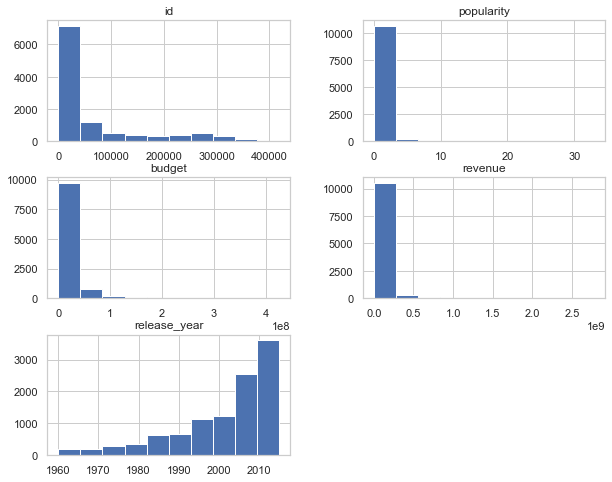

```python
# Univariate explorations

df.hist(figsize=(10,8));
```

### Research Question 1: How did the release year affect popularity?

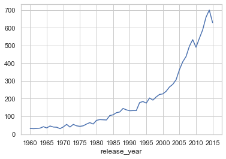

```python
#How did the release year affect popularity
#Finding the relationship between 2 variables of the release year & popularity

df.groupby('release_year').count()['popularity'].plot(xticks = np.arange(1960,2016,5))
```

### Research Question 2: Which genre has the highest popularity?

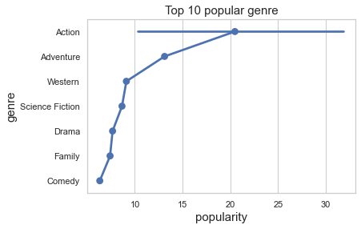

```python
#To plot the graph showing the top 10 popular genres


df.sort_values(['popularity', 'genre'], ascending= [False, True])
df.head(20)


x=df.genre[:10]
y=df.popularity[:10]

ax = sns.pointplot(x=y,y=x)
sns.set(rc={'figure.figsize':(15,10)})
ax.set_title("Top 10 popular genre",fontsize = 15)
ax.set_xlabel("popularity",fontsize = 15)
ax.set_ylabel("genre",fontsize = 15)
sns.set_style("darkgrid")
```

### Reseach Question 3: What is the average popularity of each genre?

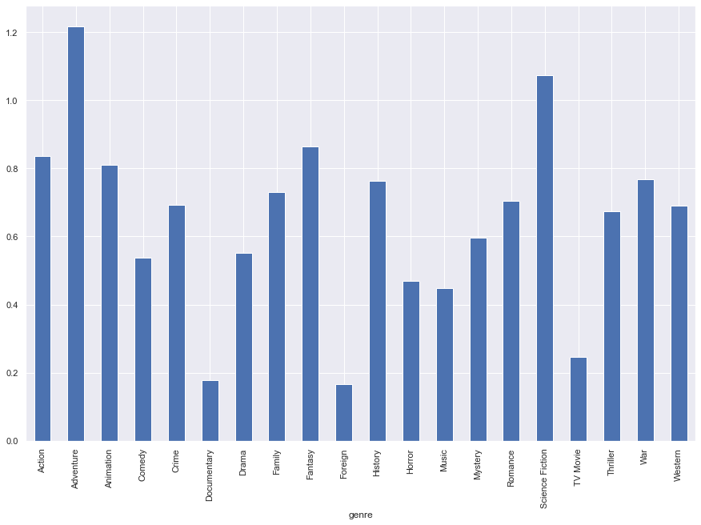

```python
#Ploting the graph of the average popular genre

df.groupby('genre').popularity.mean().plot(kind='bar')
```

```python
Action movies are not as popular amongst many people, the popular genre are adeventure and science fiction
```

### Research Question 4: Which production companies has more popular movies?

```python
#to arrange data in descending order for popularity, and ascending order for production companies.
#to view the irst 20 rows

df.sort_values(['popularity', 'production_companies'], ascending= [False, True])
df.head(20)
```

|  | id | imdb_id | popularity | budget | revenue | original_title | production_companies | release_date | release_year | genre |
| --- | --- | --- | --- | --- | --- | --- | --- | --- | --- | --- |
| 0 | 135397 | tt0369610 | 32.985763 | 150000000.0 | 1.513529e+09 | Jurassic World | Universal Studios\|Amblin Entertainment\|Legenda... | 6/9/15 | 2015 | Action |
| 1 | 76341 | tt1392190 | 28.419936 | 150000000.0 | 3.784364e+08 | Mad Max: Fury Road | Village Roadshow Pictures\|Kennedy Miller Produ... | 5/13/15 | 2015 | Action |
| 2 | 262500 | tt2908446 | 13.112507 | 110000000.0 | 2.952382e+08 | Insurgent | Summit Entertainment\|Mandeville Films\|Red Wago... | 3/18/15 | 2015 | Adventure |
| 3 | 140607 | tt2488496 | 11.173104 | 200000000.0 | 2.068178e+09 | Star Wars: The Force Awakens | Lucasfilm\|Truenorth Productions\|Bad Robot | 12/15/15 | 2015 | Action |
| 4 | 168259 | tt2820852 | 9.335014 | 190000000.0 | 1.506249e+09 | Furious 7 | Universal Pictures\|Original Film\|Media Rights ... | 4/1/15 | 2015 | Action |
| 5 | 281957 | tt1663202 | 9.110700 | 135000000.0 | 5.329505e+08 | The Revenant | Regency Enterprises\|Appian Way\|CatchPlay\|Anony... | 12/25/15 | 2015 | Western |
| 6 | 87101 | tt1340138 | 8.654359 | 155000000.0 | 4.406035e+08 | Terminator Genisys | Paramount Pictures\|Skydance Productions | 6/23/15 | 2015 | Science Fiction |
| 7 | 286217 | tt3659388 | 7.667400 | 108000000.0 | 5.953803e+08 | The Martian | Twentieth Century Fox Film Corporation\|Scott F... | 9/30/15 | 2015 | Drama |
| 8 | 211672 | tt2293640 | 7.404165 | 74000000.0 | 1.156731e+09 | Minions | Universal Pictures\|Illumination Entertainment | 6/17/15 | 2015 | Family |
| 9 | 150540 | tt2096673 | 6.326804 | 175000000.0 | 8.537086e+08 | Inside Out | Walt Disney Pictures\|Pixar Animation Studios\|W... | 6/9/15 | 2015 | Comedy |
| 10 | 206647 | tt2379713 | 6.200282 | 245000000.0 | 8.806746e+08 | Spectre | Columbia Pictures\|Danjaq\|B24 | 10/26/15 | 2015 | Action |
| 11 | 76757 | tt1617661 | 6.189369 | 176000003.0 | 1.839877e+08 | Jupiter Ascending | Village Roadshow Pictures\|Dune Entertainment\|A... | 2/4/15 | 2015 | Science Fiction |
| 12 | 264660 | tt0470752 | 6.118847 | 15000000.0 | 3.686941e+07 | Ex Machina | DNA Films\|Universal Pictures International (UP... | 1/21/15 | 2015 | Drama |
| 13 | 257344 | tt2120120 | 5.984995 | 88000000.0 | 2.436371e+08 | Pixels | Columbia Pictures\|Happy Madison Productions | 7/16/15 | 2015 | Action |
| 14 | 99861 | tt2395427 | 5.944927 | 280000000.0 | 1.405036e+09 | Avengers: Age of Ultron | Marvel Studios\|Prime Focus\|Revolution Sun Studios | 4/22/15 | 2015 | Action |
| 15 | 273248 | tt3460252 | 5.898400 | 44000000.0 | 1.557601e+08 | The Hateful Eight | Double Feature Films\|The Weinstein Company\|Fil... | 12/25/15 | 2015 | Crime |
| 16 | 260346 | tt2446042 | 5.749758 | 48000000.0 | 3.257714e+08 | Taken 3 | Twentieth Century Fox Film Corporation\|M6 Film... | 1/1/15 | 2015 | Crime |
| 17 | 102899 | tt0478970 | 5.573184 | 130000000.0 | 5.186022e+08 | Ant-Man | Marvel Studios | 7/14/15 | 2015 | Science Fiction |
| 18 | 150689 | tt1661199 | 5.556818 | 95000000.0 | 5.423514e+08 | Cinderella | Walt Disney Pictures\|Genre Films\|Beagle Pug Fi... | 3/12/15 | 2015 | Romance |
| 19 | 131634 | tt1951266 | 5.476958 | 160000000.0 | 6.505234e+08 | The Hunger Games: Mockingjay - Part 2 | Studio Babelsberg\|StudioCanal\|Lionsgate\|Walt D... | 11/18/15 | 2015 | War |

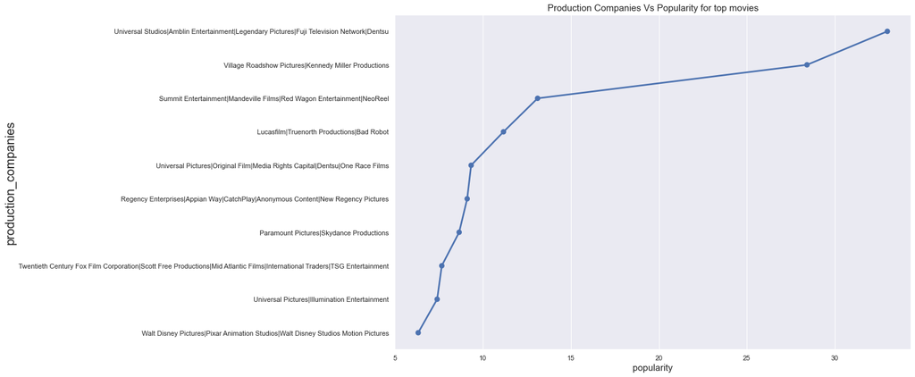

```python
#ploting the graph to show which production companies produced popular movies

x=df.production_companies[:10]
y=df.popularity[:10]

ax = sns.pointplot(x=y,y=x)
sns.set(rc={'figure.figsize':(15,10)})
ax.set_title("Production Companies Vs Popularity for top movies",fontsize = 15)
ax.set_xlabel("popularity",fontsize = 15)
ax.set_ylabel("production_companies",fontsize = 20)
sns.set_style("darkgrid")
```

```python
#To showw the count of genres produced

df['genre'].value_counts()[:20]
```

```
Drama              2453
Comedy             2319
Action             1590
Horror              915
Adventure           586
Thriller            491
Documentary         432
Animation           403
Crime               381
Fantasy             272
Science Fiction     214
Romance             186
Family              144
Mystery             125
Music               100
TV Movie             78
War                  59
History              44
Western              42
Foreign               9
Name: genre, dtype: int64
```

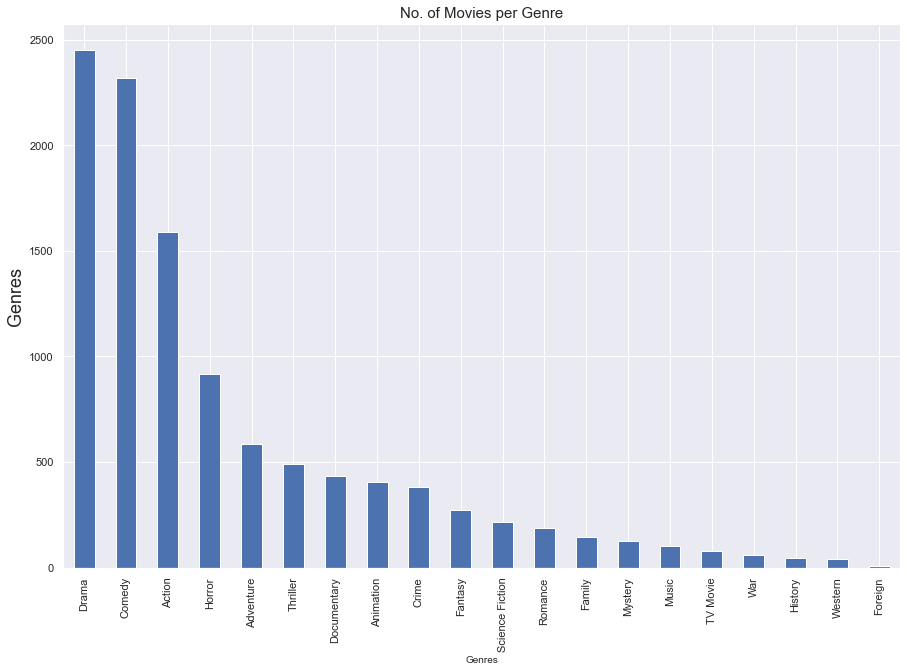

```python
#To count the number of movies produced according to genres

df['genre'].value_counts()[:20].plot(kind='bar')

plt.title("No. of Movies per Genre",fontsize=15)
plt.xlabel('Genres',fontsize=10)
plt.ylabel("Genres",fontsize= 18)
sns.set_style("whitegrid")
```

It is interesting to see the least produced movies which are TV movies, War, History, Western and Foregign.

### Steps taken during data wrangling are;

1. Loaded the dataframe.
2. Checked the description to search for an anomaly- identified in budget and columns
3. Check info to get data type, null values among othr.
4. Identified some anomalys with the budget and revenue columns
1. Counted the affected anomalys by row for the budget and revenue
2. Calculated the mean for the budget and revenue column
3. Replaced the mean value to the affected rows in budget and revenue.
4. Checked the decsription to verify if it was indeed replaced. It was.

### Steps taken during data exploration are;

Univariate exploration was done to get an understanding of each numeric column individually.

It was obvious to see that the number of movies released significantly as the years went by.

It was also discovered that the id column would be an interesting column to analyze, As we can see some form of movement there, however, this analyis did not explore that column.

### Research 2;

Action movies are easily spotted as the most popular genre. Action earned more than one spot on the top 10 popular genre.

### Research 3;

Despite the analysis in in research 2, the average popular genre appears to be Adveneture, with a close following of Science Fiction and not Action as prediced in Research 2.

This Popularity of Resrach 2 would be more favorouble in answering the Top 10 popular movies as oppsed to the Top 10 popular genre.

The shows the importance of asking the right queestion and exploring deeper.

### Research 4:

The shows the production companies that produced the top 10 popular movies.

Universal Studios|Amblin Entertainment|Legenda. produced the most popular popular movies in this dataframe,

### Reserach 5:

This shows the number of movies produced per genre, and we can see that Drama and Comedy has the highest number of count,

However, they are not the top 3 popular movies nor top 3 average popularity of genre

### Limitation

Research Question 2 was not properly worded thus producing limited result